# HPAStainR Package Vignette

Tim O. Nieuwenhuis

2020-06-16

HPAStainR is a package designed to query the pathologist scored staining data of multiple proteins/genes at once in the Human Protein Atlas (HPA). This vignette will walk you through:

- How to download the data required to run HPAStainR
- How to run HPAStainR as a function
- How to run HPAStainR as a Shiny App

# Preparing data for HPAStainR

## Downloading data from the website

The first step required to run HPAStainR is downloading HPA’s normal tissue staining data and their cancer data. While available online, HPAStainR has a function that can download and load the data for you.

```r
library(HPAStainR)
HPA_data <- HPA_data_downloader(tissue_type = "both", save_file = T)
```

The above function has downloaded both the normal tissue and cancer data. As I selected save, but did not give an argument for `save location` this results both files being saved to the current working directory. The data has also been unzipped and loaded into the object HPA_dat as a list of dataframes called `hpa_dat` and `cancer_dat` which hold the normal tissue and cancer tissue data respectively. If the code is ran again it will use the previously saved files and not redownload them.

### Head of normal tissue

| Gene | Gene.name | Tissue | Cell.type | Level | Reliability |
| --- | --- | --- | --- | --- | --- |
| ENSG00000000003 | TSPAN6 | adipose tissue | adipocytes | Not detected | Approved |
| ENSG00000000003 | TSPAN6 | adrenal gland | glandular cells | Not detected | Approved |
| ENSG00000000003 | TSPAN6 | appendix | glandular cells | Medium | Approved |
| ENSG00000000003 | TSPAN6 | appendix | lymphoid tissue | Not detected | Approved |
| ENSG00000000003 | TSPAN6 | bone marrow | hematopoietic cells | Not detected | Approved |
| ENSG00000000003 | TSPAN6 | breast | adipocytes | Not detected | Approved |
| ENSG00000000003 | TSPAN6 | breast | glandular cells | High | Approved |
| ENSG00000000003 | TSPAN6 | breast | myoepithelial cells | Not detected | Approved |
| ENSG00000000003 | TSPAN6 | bronchus | respiratory epithelial cells | High | Approved |
| ENSG00000000003 | TSPAN6 | caudate | glial cells | Not detected | Approved |

### Head of cancer tissue (columns 1-7)

| Gene | Gene.name | Cancer | High | Medium | Low | Not.detected |
| --- | --- | --- | --- | --- | --- | --- |
| ENSG00000000003 | TSPAN6 | breast cancer | 1 | 7 | 2 | 2 |
| ENSG00000000003 | TSPAN6 | carcinoid | 0 | 1 | 1 | 2 |
| ENSG00000000003 | TSPAN6 | cervical cancer | 11 | 1 | 0 | 0 |
| ENSG00000000003 | TSPAN6 | colorectal cancer | 0 | 6 | 2 | 2 |
| ENSG00000000003 | TSPAN6 | endometrial cancer | 10 | 2 | 0 | 0 |
| ENSG00000000003 | TSPAN6 | glioma | 0 | 0 | 0 | 11 |
| ENSG00000000003 | TSPAN6 | head and neck cancer | 0 | 3 | 1 | 0 |
| ENSG00000000003 | TSPAN6 | liver cancer | 4 | 5 | 1 | 0 |
| ENSG00000000003 | TSPAN6 | lung cancer | 8 | 4 | 0 | 0 |
| ENSG00000000003 | TSPAN6 | lymphoma | 0 | 0 | 0 | 11 |

# Using HPAStainR

## Using the HPAStainR function

Now that the data is available you can now us the HPAStainR function. This requires a list of proteins or genes you are interested in. In this example we’re going to use pancreatic enzymes PRSS1, PNLIP, CELA3A, and the hormone PRL.

```r
gene_list = c("PRSS1", "PNLIP","CELA3A", "PRL")

stainR_out <- HPAStainR::HPAStainR(gene_list = gene_list,
          hpa_dat = HPA_data$hpa_dat,
          cancer_dat = HPA_data$cancer_dat,
          cancer_analysis = "both",
          stringency = "normal")


head(stainR_out, 10)
```

```
#> # A tibble: 10 x 11
#>    cell_type percent_high_ex~ percent_medium_~ percent_low_exp~ percent_not_det~
#>    <chr>                <dbl>            <dbl>            <dbl>            <dbl>
#>  1 "PANCREA~             0.75             0                0                0.25
#>  2 "PITUITA~             0.25             0                0                0
#>  3 "DUODENU~             0                0.25             0                0.75
#>  4 "SMALL I~             0                0.25             0                0.75
#>  5 "COLON -~             0                0                0.25             0.75
#>  6 "head an~             0                0.07             0                0.93
#>  7 "pancrea~             0                0.02             0                0.98
#>  8 "ADIPOSE~             0                0                0                1
#>  9 "ADRENAL~             0                0                0                1
#> 10 "APPENDI~             0                0                0                1
#> # ... with 6 more variables: number_of_proteins <dbl>, tested_proteins <chr>,
#> #   detected_proteins <chr>, staining_score <dbl>, p_val <chr>, p_val_adj <chr>
```

The **staining score** an arbitrary rank of staining weighted on how highly a protein stained. See the manual for the equation and further information.

# Using the HPAStainR Shiny app

Another way to use HPAStainR is as a [Shiny app](https://32tim32.shinyapps.io/HPAStainR/), and the function shiny_HPAStainR allows you to run a local version of the app:

**Note:** If you want the tab from the online Shiny that gives you the stained : tested ratio of proteins, make sure to run the below code and insert the resulting object in the third argument (`cell_type_data`) of shiny_HPAStainR

```r
hpa_summary <- hpa_summary_maker(hpa_dat = HPA_data$hpa_dat)
```

## Run the Shiny app

```r
shiny_HPAStainR(hpa_dat = HPA_data$hpa_dat,
                cancer_dat = HPA_data$cancer_dat,
                cell_type_data = hpa_summary)
```

### A window should open like that below

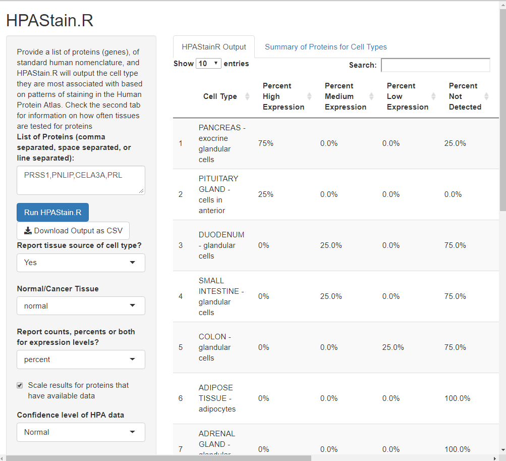

You should now be able to query whatever list of proteins you like and can easily rank them on whatever column you wish. Also all of the options from the functions are modifiable on the left hand side panel.

Any questions? Feel free to contact me at tnieuwe1[@]jhmi.edu